# Análise Completa de Dados de Produção Automotiva

Analista

2025-02-08

# Carregamento e Exploração Inicial dos Dados

## Carregamento dos Datasets

```r
# Carregamento dos dados
df_falhas <- read.csv("InteliFalhas.csv", sep = ",", header = TRUE)
df_results <- read.csv("InteliResultados.csv", sep = ",", header = TRUE)
df_veiculo <- read.csv("InteliVeiculo.csv", sep = ",", header = TRUE)
df_status <- read.csv("InteliStatus.csv", sep = ",", header = TRUE)

# Verificação das dimensões
dim(df_falhas)
```

```
## [1] 679073     12
```

```r
dim(df_status)
```

```
## [1] 7245975       3
```

```r
dim(df_veiculo)
```

```
## [1] 139707      6
```

```r
dim(df_results)
```

```
## [1] 1932313       5
```

## Visualização Inicial e Estrutura

```r
# Primeiras linhas de cada dataset
list(
  "Falhas" = head(df_falhas),
  "Resultados" = head(df_results),
  "Veículos" = head(df_veiculo),
  "Status" = head(df_status)
)
```

```
## $Falhas
##             ID              DATA.DETECCAO   PONTO   LOC_ID
## 1 2024-3712154 2010-01-29-02.25.25.000000 RODAGEM     5559
## 2 2024-3722068 2010-01-29-02.38.57.000000 RODAGEM     5559
## 3 2024-3732080 2010-01-29-02.44.54.000000 RODAGEM     7057
## 4 2024-3732079 2010-01-29-02.53.28.000000 RODAGEM     5851
## 5 2024-3711076 2010-01-29-02.54.22.000000 RODAGEM     4661
## 6 2024-3732094 2010-01-29-04.04.56.000000 RODAGEM 98761528
##                                      LOC POS_ID      POS TYPE_ID
## 1                         Tampa traseira     -2               70
## 2                         Tampa traseira     -2               70
## 3                  Revestimento coluna A      5  direita      70
## 4                         Porta traseira      5  direita      70
## 5               Alavanca do freio manual     -2                5
## 6 Regulador de altura cinto de segurança      3 esquerda      31
```

[output cut: 41 more lines]

```r
# Estrutura detalhada
glimpse(df_falhas)
```

```
## Rows: 679,073
## Columns: 12
## $ ID            <chr> "2024-3712154", "2024-3722068", "2024-3732080", "2024-37320…
## $ DATA.DETECCAO <chr> "2010-01-29-02.25.25.000000", "2010-01-29-02.38.57.000000",…
## $ PONTO         <chr> "RODAGEM", "RODAGEM", "RODAGEM", "RODAGEM", "RODAGEM", "ROD…
## $ LOC_ID        <int> 5559, 5559, 7057, 5851, 4661, 98761528, 51371, 5851, 7018, …
## $ LOC           <chr> "Tampa traseira", "Tampa traseira", "Revestimento coluna A"…
## $ POS_ID        <int> -2, -2, 5, 5, -2, 3, 3, 5, 4, 3, 10, 10, 10, 17, 10, 10, 10…
## $ POS           <chr> "", "", "direita", "direita", "", "esquerda", "esquerda", "…
## $ TYPE_ID       <int> 70, 70, 70, 70, 5, 31, 70, 70, 70, 70, 89, 4, 4, 185, 89, 1…
## $ TYPE_TEXT     <chr> "070 - Ruído", "070 - Ruído", "070 - Ruído", "070 - Ruído",…
## $ VIEW_ID       <dbl> NA, NA, NA, NA, NA, NA, NA, NA, NA, NA, 691, 748, 764, 744,…
## $ COLUNA        <chr> "", "", "", "", "", "", "", "", "", "", "G", "D", "E", "C",…
## $ LINHA         <int> NA, NA, NA, NA, NA, NA, NA, NA, NA, NA, 2, 2, 6, 2, 2, 4, 4…
```

```r
glimpse(df_status)
```

```
## Rows: 7,245,975
## Columns: 3
## $ ID          <chr> "2024-1422099", "2024-1422099", "2024-1431276", "2024-1431276…
## $ STATUS      <chr> "R210", "R212", "R213", "R215", "R300", "R213", "R215", "R210…
## $ STATUS_DATA <chr> "2024-04-02-00.00.37.000000", "2024-04-02-00.00.37.000000", "…
```

```r
glimpse(df_veiculo)
```

```
## Rows: 139,707
## Columns: 6
## $ ID        <chr> "2024-1322010", "2024-1332013", "2024-1332022", "2024-1332321",…
## $ MODELL    <chr> "R111Q4  ", "R111Q4  ", "R111Q4  ", "R111Q4  ", "R111Q4  ", "R1…
## $ FARBAU    <chr> "B4B4", "B4B4", "B4B4", "B4B4", "B4B4", "B4B4", "B4B4", "B4B4",…
## $ FARBIN    <chr> "XK", "XK", "XK", "XK", "XK", "XK", "XK", "XK", "XK", "XK", "XK…
## $ ZIEL_LAND <chr> "VY ", "VY ", "VY ", "VY ", "VY ", "VY ", "VY ", "VY ", "VY ", …
## $ PR        <chr> "LRV:AV1 MSF:AW0 AUS:A8A BLB:B1D TPL:B41 ASG:EA0 ECO:EF0 ONL:EL…
```

```r
glimpse(df_results)
```

```
## Rows: 1,932,313
## Columns: 5
## $ ID                 <chr> "2024-3821101", "2024-3851264", "2024-3851264", "2024-…
## $ RESULT_ID          <chr> "53P007", "53P007", "53P007", "53P007", "53P007", "53P…
## $ RESULT_DESCRIPTION <chr> "ABASTEC. CÂMBIO", "ABASTEC. CÂMBIO", "ABASTEC. CÂMBIO…
## $ CAPTURE_TIME       <chr> "2019-02-14-08.20.57.000000", "2019-02-14-08.31.27.000…
## $ STATUS             <chr> "NOK", "NOK", "NOK", "NOK", "NOK", "NOK", "NOK", "NOK"…
```

# Análise Descritiva dos Dados

## Resumo Estatístico

```r
# Resumos estatísticos
summary(df_falhas)
```

```
##       ID            DATA.DETECCAO         PONTO               LOC_ID
##  Length:679073      Length:679073      Length:679073      Min.   :    1001
##  Class :character   Class :character   Class :character   1st Qu.:    5145
##  Mode  :character   Mode  :character   Mode  :character   Median :    5559
##                                                           Mean   : 3520407
##                                                           3rd Qu.:    5851
##                                                           Max.   :99008995
##
##      LOC                POS_ID            POS               TYPE_ID
##  Length:679073      Min.   :     -2   Length:679073      Min.   :       1
##  Class :character   1st Qu.:      1   Class :character   1st Qu.:      39
##  Mode  :character   Median :     10   Mode  :character   Median :      89
##                     Mean   :  49464                      Mean   : 5766978
##                     3rd Qu.:     17                      3rd Qu.:     126
##                     Max.   :9799976                      Max.   :99008934
##
##   TYPE_TEXT            VIEW_ID         COLUNA              LINHA
##  Length:679073      Min.   :661.0   Length:679073      Min.   :1.00
##  Class :character   1st Qu.:673.0   Class :character   1st Qu.:2.00
##  Mode  :character   Median :689.0   Mode  :character   Median :3.00
##                     Mean   :699.3                      Mean   :3.25
##                     3rd Qu.:723.0                      3rd Qu.:4.00
##                     Max.   :778.0                      Max.   :6.00
##                     NA's   :98563                      NA's   :98564
```

```r
summary(df_veiculo)
```

```
##       ID               MODELL             FARBAU             FARBIN
##  Length:139707      Length:139707      Length:139707      Length:139707
##  Class :character   Class :character   Class :character   Class :character
##  Mode  :character   Mode  :character   Mode  :character   Mode  :character
##   ZIEL_LAND              PR
##  Length:139707      Length:139707
##  Class :character   Class :character
##  Mode  :character   Mode  :character
```

```r
summary(df_results)
```

```
##       ID             RESULT_ID         RESULT_DESCRIPTION CAPTURE_TIME
##  Length:1932313     Length:1932313     Length:1932313     Length:1932313
##  Class :character   Class :character   Class :character   Class :character
##  Mode  :character   Mode  :character   Mode  :character   Mode  :character
##     STATUS
##  Length:1932313
##  Class :character
##  Mode  :character
```

```r
summary(df_status)
```

```
##       ID               STATUS          STATUS_DATA
##  Length:7245975     Length:7245975     Length:7245975
##  Class :character   Class :character   Class :character
##  Mode  :character   Mode  :character   Mode  :character
```

```r
# Verificação de dados vazios
colSums(is.na(df_falhas))
```

```
##            ID DATA.DETECCAO         PONTO        LOC_ID           LOC
##             0             0             0             0             0
##        POS_ID           POS       TYPE_ID     TYPE_TEXT       VIEW_ID
##             0             0             0             0         98563
##        COLUNA         LINHA
##             0         98564
```

```r
colSums(is.na(df_results))
```

```
##                 ID          RESULT_ID RESULT_DESCRIPTION       CAPTURE_TIME
##                  0                  0                  0                  0
##             STATUS
##                  0
```

```r
colSums(is.na(df_status))
```

```
##          ID      STATUS STATUS_DATA
##           0           0           0
```

```r
colSums(is.na(df_veiculo))
```

```
##        ID    MODELL    FARBAU    FARBIN ZIEL_LAND        PR
##         0         0         0         0         0         0
```

## Análise de Valores Únicos

```r
# Análise de valores únicos por coluna
df_veiculo %>% summarise(across(where(is.character), n_distinct))
```

```
##       ID MODELL FARBAU FARBIN ZIEL_LAND  PR
## 1 139704     12      8      3        16 223
```

```r
df_veiculo %>% count(MODELL, sort = TRUE)
```

```
##      MODELL     n
## 1  R111Q4   70878
## 2  BZ31T4   19890
## 3  BZ33K3   13927
## 4  BZ32K3    8319
## 5  BZ3SK3    7081
## 6  R11SQ4    4201
## 7  BZ33D3    3737
## 8  BZ32K4    2876
## 9  BZ32D3    2589
## 10 R11AQ4    2155
## 11 BZ38Q4    2028
## 12 BZ32T4    2026
```

```r
df_veiculo %>% count(FARBAU, sort = TRUE)
```

```
##   FARBAU     n
## 1   B4B4 62141
## 2   2R2R 31778
## 3   7Z7Z 26854
## 4   A1A1 12312
## 5   6K6K  2421
## 6   B4A1  1846
## 7   2RA1  1771
## 8   6KA1   584
```

```r
df_veiculo %>% count(FARBIN, sort = TRUE)
```

```
##   FARBIN     n
## 1     XK 99152
## 2     WK 22891
## 3     WJ 17664
```

```r
df_veiculo %>% count(ZIEL_LAND, sort = TRUE)
```

```
##    ZIEL_LAND      n
## 1        VY  110363
## 2        AR   17415
## 3        ME    5550
## 4        KC    2386
## 5        VR    1481
## 6        BRA    877
## 7        EH     627
## 8        ARG    423
## 9        PG     220
## 10       KL     170
## 11       PE      74
## 12       MEX     67
## 13       ZK      20
## 14       WG      19
## 15       WB      10
## 16       BY       5
```

```r
df_veiculo %>% count(PR, sort = TRUE)
```

[output not shown]

[output cut: 433 more lines]

# Análise Univariada

## Preparação dos Dados

```r
# Criação do dataset único por ID
df_veiculo_unique <- df_veiculo %>%
  group_by(ID) %>%
  slice(1) %>%
  ungroup()

# Análise de falhas por veículo
falhas_por_veiculo <- df_falhas %>%
  group_by(ID) %>%
  summarise(total_falhas = n()) %>%
  ungroup()
```

## Distribuição de Falhas

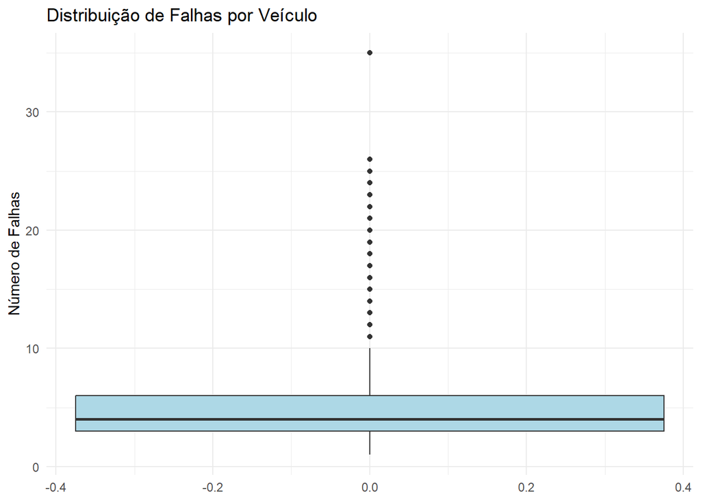

```r
# Boxplot de falhas por veículo
ggplot(falhas_por_veiculo, aes(y = total_falhas)) +
  geom_boxplot(fill = "lightblue") +
  labs(title = "Distribuição de Falhas por Veículo",
       y = "Número de Falhas") +
  theme_minimal()
```

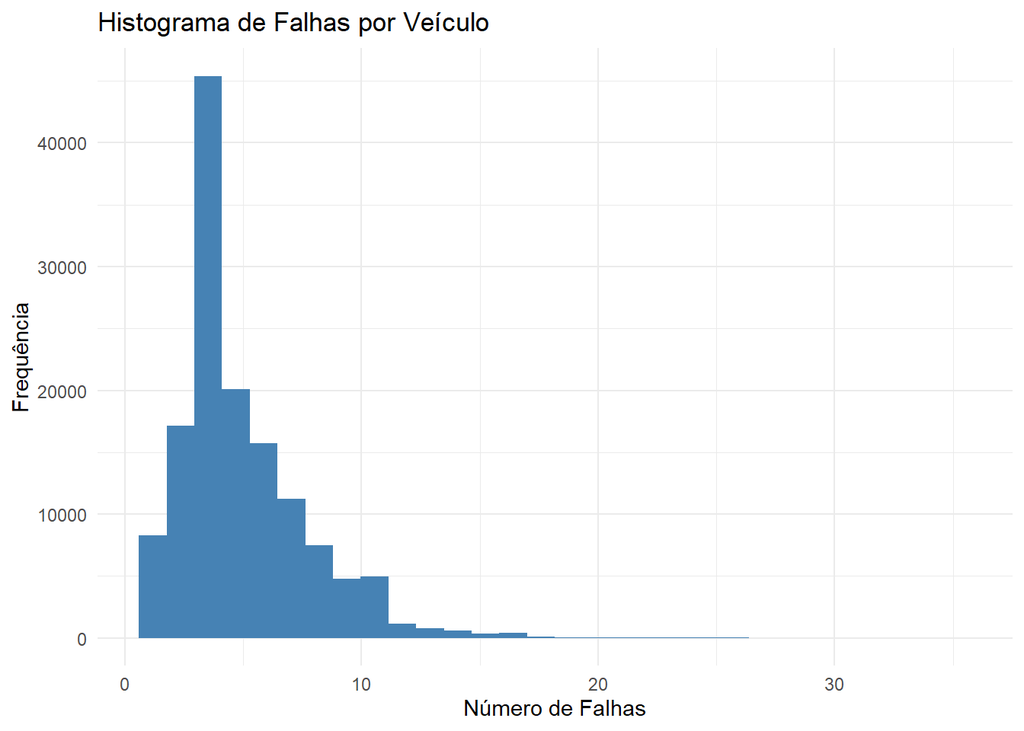

```r
# Histograma de falhas
ggplot(falhas_por_veiculo, aes(x = total_falhas)) +
  geom_histogram(fill = "steelblue", bins = 30) +
  labs(title = "Histograma de Falhas por Veículo",
       x = "Número de Falhas",
       y = "Frequência") +
  theme_minimal()
```

## Outliers em Falhas

```r
# Identificação de outliers
outliers <- boxplot.stats(falhas_por_veiculo$total_falhas)$out
veiculos_outliers <- falhas_por_veiculo %>%
  filter(total_falhas %in% outliers) %>%
  arrange(desc(total_falhas))

print("Veículos com número atípico de falhas:")
```

```
## [1] "Veículos com número atípico de falhas:"
```

```r
print(head(veiculos_outliers))
```

```
## # A tibble: 6 × 2
##   ID           total_falhas
##   <chr>               <int>
## 1 2024-1431148           35
## 2 2024-2011068           26
## 3 2024-2811033           26
## 4 2024-4512097           26
## 5 2025-0332129           26
## 6 2024-3552075           25
```

## Relação Falhas vs Modelo

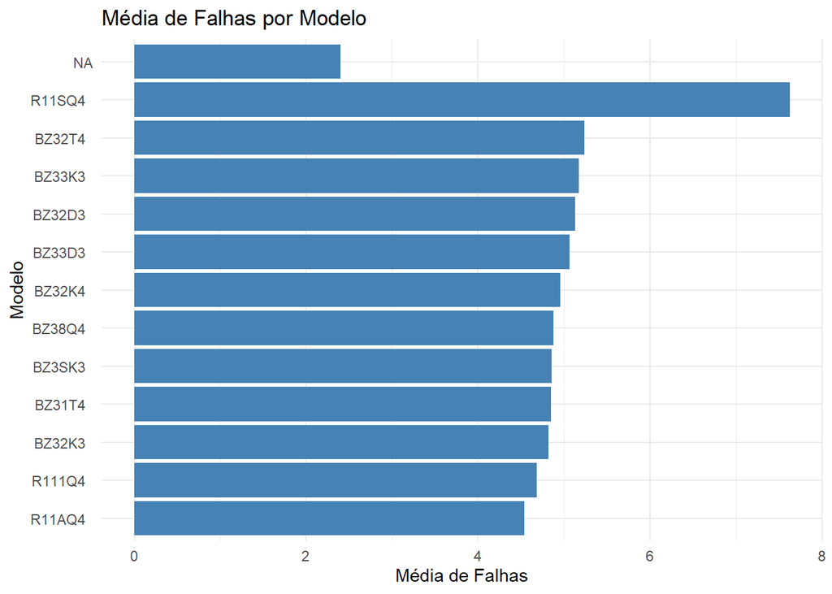

```r
falhas_por_modelo_corrigido <- df_falhas %>%
  left_join(df_veiculo_unique, by = "ID") %>%
  group_by(MODELL) %>%
  summarise(
    total_veiculos = n_distinct(ID),
    total_falhas = n(),
    media_falhas_por_veiculo = total_falhas/total_veiculos,
    tipos_falhas_distintos = n_distinct(TYPE_ID),
    locais_falhas_distintos = n_distinct(LOC_ID)
  ) %>%
  arrange(desc(media_falhas_por_veiculo))

ggplot(falhas_por_modelo_corrigido,
       aes(x = reorder(MODELL, media_falhas_por_veiculo),
           y = media_falhas_por_veiculo)) +
  geom_bar(stat = "identity", fill = "steelblue") +
  coord_flip() +
  theme_minimal() +
  labs(title = "Média de Falhas por Modelo",
       x = "Modelo",
       y = "Média de Falhas")
```

## Análise de Correlação

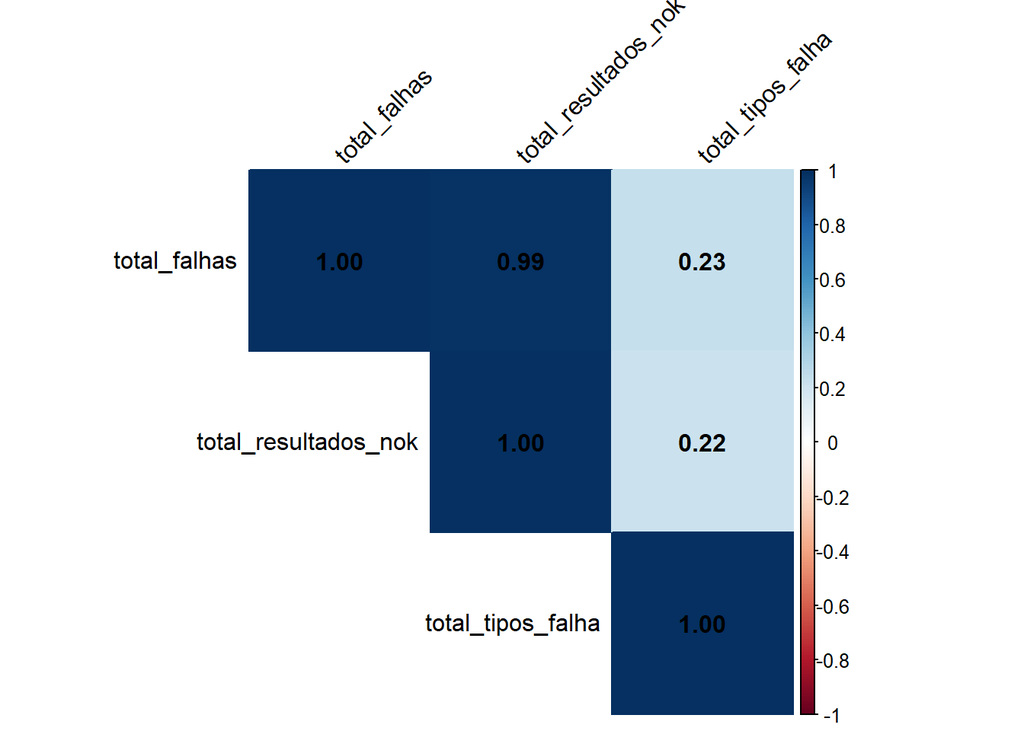

```r
# Correlação entre variáveis numéricas
dados_correlacao <- df_falhas %>%
  left_join(df_results, by = "ID") %>%
  group_by(ID) %>%
  summarise(
    total_falhas = n(),
    total_resultados_nok = sum(STATUS == "NOK", na.rm = TRUE),
    total_tipos_falha = n_distinct(TYPE_ID)
  )

matriz_correlacao <- cor(dados_correlacao[,-1], use = "complete.obs")
corrplot(matriz_correlacao, method = "color", type = "upper",
         addCoef.col = "black", tl.col = "black", tl.srt = 45)
```

```r
## Análise de Correlação Expandida
dados_correlacao_expandida <- df_falhas %>%
  left_join(df_veiculo_unique, by = "ID") %>%
  group_by(ID) %>%
  summarise(
    total_falhas = n(),
    tipos_falhas_distintos = n_distinct(TYPE_ID),
    locais_falhas_distintos = n_distinct(LOC_ID)
  ) %>%
  left_join(
    df_results %>%
      group_by(ID) %>%
      summarise(
        total_resultados = n(),
        resultados_nok = sum(STATUS == "NOK", na.rm = TRUE)
      ),
    by = "ID"
  ) %>%
  left_join(
    df_veiculo_unique %>%
      select(ID, MODELL, FARBAU, FARBIN, ZIEL_LAND) %>%
      mutate(
        modelo_num = as.numeric(factor(MODELL)),
        cor_externa_num = as.numeric(factor(FARBAU)),
        cor_interna_num = as.numeric(factor(FARBIN)),
        pais_num = as.numeric(factor(ZIEL_LAND))
      ),
    by = "ID"
  )
```

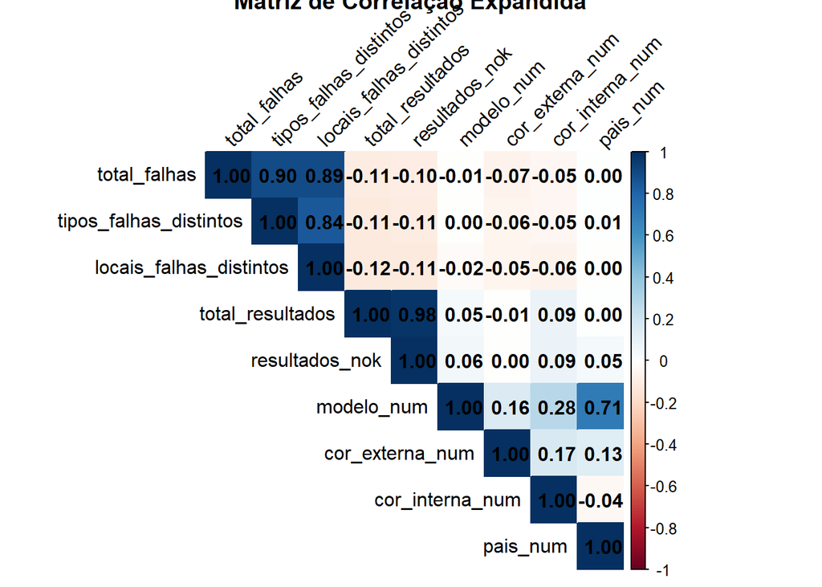

```r
variaveis_numericas <- dados_correlacao_expandida %>%
  select(total_falhas, tipos_falhas_distintos, locais_falhas_distintos,
         total_resultados, resultados_nok, modelo_num,
         cor_externa_num, cor_interna_num, pais_num)

matriz_correlacao_expandida <- cor(variaveis_numericas, use = "complete.obs")

# Visualização da matriz de correlação
corrplot(matriz_correlacao_expandida,
         method = "color",
         type = "upper",
         addCoef.col = "black",
         tl.col = "black",
         tl.srt = 45,
         title = "Matriz de Correlação Expandida")
```

```r
# Análise das correlações mais fortes
correlacoes_ordenadas <- as.data.frame(as.table(matriz_correlacao_expandida)) %>%
  filter(Var1 != Var2) %>%
  arrange(desc(abs(Freq)))

print("Top 10 correlações mais fortes:")
```

```
## [1] "Top 10 correlações mais fortes:"
```

```r
head(correlacoes_ordenadas, 10)
```

```
##                       Var1                    Var2      Freq
## 1           resultados_nok        total_resultados 0.9750568
## 2         total_resultados          resultados_nok 0.9750568
## 3   tipos_falhas_distintos            total_falhas 0.8996744
## 4             total_falhas  tipos_falhas_distintos 0.8996744
## 5  locais_falhas_distintos            total_falhas 0.8925231
## 6             total_falhas locais_falhas_distintos 0.8925231
## 7  locais_falhas_distintos  tipos_falhas_distintos 0.8447971
## 8   tipos_falhas_distintos locais_falhas_distintos 0.8447971
## 9                 pais_num              modelo_num 0.7064740
## 10              modelo_num                pais_num 0.7064740
```

# Análise Multivariada

## Análise de Componentes Principais

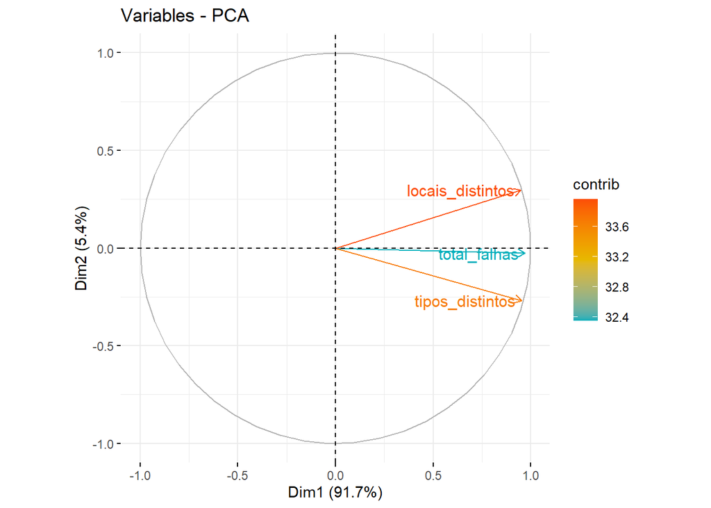

```r
# Preparação para PCA
dados_pca <- df_falhas %>%
  left_join(df_veiculo_unique, by = "ID") %>%
  group_by(ID) %>%
  summarise(
    total_falhas = n(),
    tipos_distintos = n_distinct(TYPE_ID),
    locais_distintos = n_distinct(LOC_ID)
  ) %>%
  na.omit()

# PCA
pca_result <- PCA(dados_pca[,-1], graph = FALSE)

# Visualização
fviz_pca_var(pca_result,
             col.var = "contrib",
             gradient.cols = c("#00AFBB", "#E7B800", "#FC4E07"),
             repel = TRUE)
```

```r
# Sumário da variância explicada
print("Variância explicada por componente:")
```

```
## [1] "Variância explicada por componente:"
```

```r
print(pca_result$eig)
```

```
##        eigenvalue percentage of variance cumulative percentage of variance
## comp 1 2.74983131              91.661044                          91.66104
## comp 2 0.16131870               5.377290                          97.03833
## comp 3 0.08884999               2.961666                         100.00000
```

# Análises Específicas Adicionais

## Análise Temporal de Falhas

### Também é possível analisar um modelo especifico só passando o parametro pro gráfico

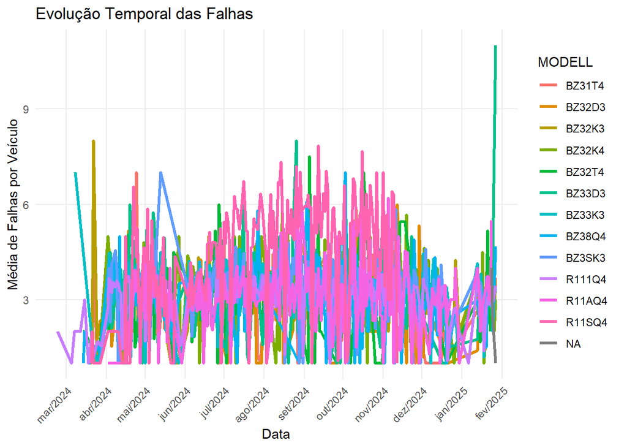

```r
falhas_temporais <- df_falhas %>%
  left_join(df_veiculo_unique, by = "ID") %>%
  mutate(data = as.Date(substr(DATA.DETECCAO, 1, 10))) %>%
  group_by(data, MODELL) %>%
  summarise(
    veiculos_afetados = n_distinct(ID),
    total_falhas = n(),
    media_falhas_por_veiculo = total_falhas/veiculos_afetados,
    .groups = 'drop'
  )

ggplot(falhas_temporais %>%
         filter(data >= "2024-01-01"),
       aes(x = data, y = media_falhas_por_veiculo, color = MODELL)) +
  geom_line(size = 1.2) +
  theme_minimal() +
  scale_x_date(date_breaks = "1 month", date_labels = "%b/%Y") +
  theme(
    legend.position = "right",
    axis.text.x = element_text(angle = 45, hjust = 1),
    panel.grid.minor = element_blank()
  ) +
  labs(
    title = "Evolução Temporal das Falhas",
    x = "Data",
    y = "Média de Falhas por Veículo"
  )
```

## Análise por País de Destino

```r
falhas_por_pais <- df_falhas %>%
  left_join(df_veiculo_unique, by = "ID") %>%
  group_by(ZIEL_LAND, TYPE_TEXT) %>%
  summarise(
    veiculos_afetados = n_distinct(ID),
    total_falhas = n(),
    media_falhas_por_veiculo = total_falhas/veiculos_afetados,
    .groups = 'drop'
  ) %>%
  arrange(ZIEL_LAND, desc(media_falhas_por_veiculo))

print("Top 5 tipos de falhas por país:")
```

```
## [1] "Top 5 tipos de falhas por país:"
```

```r
falhas_por_pais %>%
  group_by(ZIEL_LAND) %>%
  slice_max(order_by = total_falhas, n = 5)
```

```
## # A tibble: 93 × 5
## # Groups:   ZIEL_LAND [17]
##    ZIEL_LAND TYPE_TEXT        veiculos_afetados total_falhas media_falhas_por_vei…¹
##    <chr>     <chr>                        <int>        <int>                  <dbl>
##  1 "AR "     "126 - Sujeiras…              9476        15840                   1.67
##  2 "AR "     "004 - Amassado"              7441        10719                   1.44
##  3 "AR "     "081 - Caroço"                6056         7926                   1.31
##  4 "AR "     "125 - Amassado…              2957         3579                   1.21
##  5 "AR "     "040 - Ajuste I…              2316         2993                   1.29
##  6 "ARG"     "126 - Sujeiras…               189          305                   1.61
##  7 "ARG"     "081 - Caroço"                 126          170                   1.35
##  8 "ARG"     "004 - Amassado"               121          148                   1.22
##  9 "ARG"     "087 - Ponto de…                53           66                   1.25
## 10 "ARG"     "125 - Amassado…                45           59                   1.31
## # ℹ 83 more rows
## # ℹ abbreviated name: ¹media_falhas_por_veiculo
```

## Análise de Cores Externas

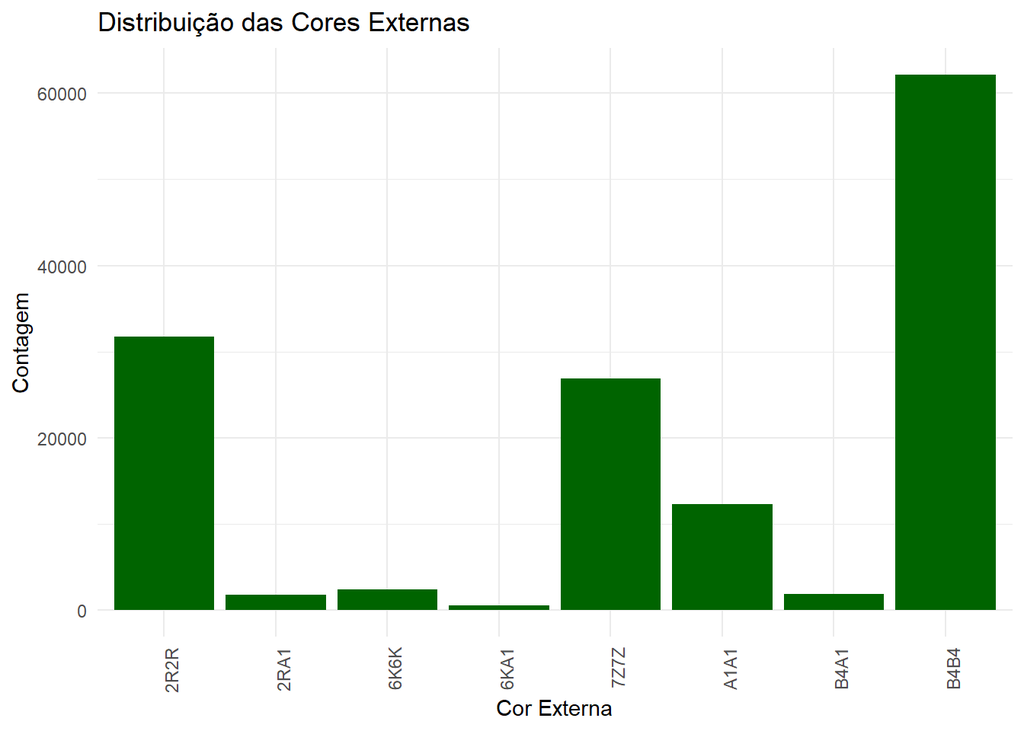

```r
# Distribuição das Cores Externas
ggplot(df_veiculo, aes(x = FARBAU)) +
  geom_bar(fill = "darkgreen") +
  theme_minimal() +
  labs(title = "Distribuição das Cores Externas",
       x = "Cor Externa",
       y = "Contagem") +
  theme(axis.text.x = element_text(angle = 90, hjust = 1))
```

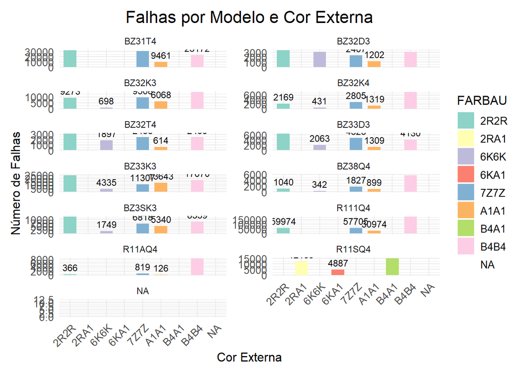

```r
# Análise de falhas por modelo e cor externa
falhas_por_modelo_cor <- df_falhas %>%
  left_join(df_veiculo_unique, by = "ID") %>%
  group_by(MODELL, FARBAU) %>%
  summarise(falhas_por_modelo = n(), .groups = 'drop') %>%
  arrange(desc(falhas_por_modelo))

# Gráfico de Falhas por Modelo e Cor Externa
ggplot(falhas_por_modelo_cor,
       aes(x = FARBAU, y = falhas_por_modelo, fill = FARBAU)) +
  geom_bar(stat = "identity", position = "dodge", width = 0.7) +
  scale_fill_brewer(palette = "Set3") +
  theme_minimal() +
  theme(
    axis.text.x = element_text(angle = 45, hjust = 1),
    axis.title = element_text(size = 12),
    axis.text = element_text(size = 10),
    legend.title = element_text(size = 12),
    legend.text = element_text(size = 10),
    plot.title = element_text(size = 16, hjust = 0.5),
    plot.margin = margin(10, 10, 10, 10)
  ) +
  geom_text(aes(label = falhas_por_modelo),
            position = position_dodge(width = 0.75),
            vjust = -0.5,
            size = 3) +
  labs(title = "Falhas por Modelo e Cor Externa",
       x = "Cor Externa",
       y = "Número de Falhas") +
  facet_wrap(~ MODELL, scales = "free_y", ncol = 2)
```

```r
# Análise estatística por cor
estatisticas_cor <- df_falhas %>%
  left_join(df_veiculo_unique, by = "ID") %>%
  group_by(FARBAU) %>%
  summarise(
    total_veiculos = n_distinct(ID),
    total_falhas = n(),
    media_falhas = total_falhas/total_veiculos,
    .groups = 'drop'
  ) %>%
  arrange(desc(media_falhas))

print("Estatísticas de falhas por cor externa:")
```

```
## [1] "Estatísticas de falhas por cor externa:"
```

```r
print(estatisticas_cor)
```

```
## # A tibble: 9 × 4
##   FARBAU total_veiculos total_falhas media_falhas
##   <chr>           <int>        <int>        <dbl>
## 1 6KA1              584         4887         8.37
## 2 B4A1             1844        14990         8.13
## 3 2RA1             1769        12139         6.86
## 4 6K6K             2416        14614         6.05
## 5 A1A1            12279        70955         5.78
## 6 7Z7Z            26650       131419         4.93
## 7 2R2R            31586       154737         4.90
## 8 B4B4            61585       275320         4.47
## 9 <NA>                5           12         2.4
```

```r
## Análise de Configurações (PR)
```

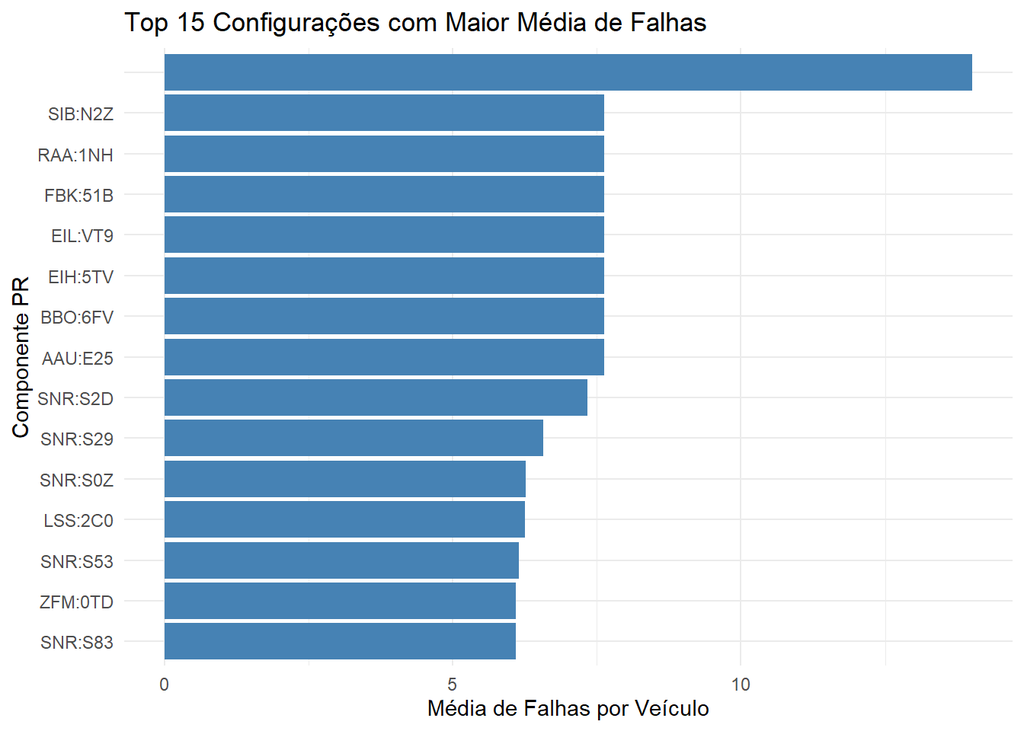

```r
# Análise de falhas por componente PR
falhas_config <- df_falhas %>%
  left_join(df_veiculo_unique, by = "ID") %>%
  mutate(
    pr_components = strsplit(PR, " ")
  ) %>%
  unnest(pr_components) %>%
  group_by(pr_components) %>%
  summarise(
    veiculos_afetados = n_distinct(ID),
    total_falhas = n(),
    media_falhas_por_veiculo = total_falhas/veiculos_afetados,
    .groups = 'drop'
  ) %>%
  arrange(desc(media_falhas_por_veiculo))

# Visualização das top configurações problemáticas
ggplot(head(falhas_config, 15),
       aes(x = reorder(pr_components, media_falhas_por_veiculo),
           y = media_falhas_por_veiculo)) +
  geom_bar(stat = "identity", fill = "steelblue") +
  coord_flip() +
  theme_minimal() +
  labs(title = "Top 15 Configurações com Maior Média de Falhas",
       x = "Componente PR",
       y = "Média de Falhas por Veículo")
```

```r
# Análise detalhada de tipos de falha por PR
pr_tipo_falha <- df_falhas %>%
  left_join(df_veiculo_unique, by = "ID") %>%
  mutate(
    pr_components = strsplit(PR, " ")
  ) %>%
  unnest(pr_components) %>%
  group_by(pr_components, TYPE_TEXT) %>%
  summarise(
    total_ocorrencias = n(),
    veiculos_distintos = n_distinct(ID),
    .groups = 'drop'
  ) %>%
  arrange(pr_components, desc(total_ocorrencias))

print("Top 15 combinações PR-Tipo de Falha mais frequentes:")
```

```
## [1] "Top 15 combinações PR-Tipo de Falha mais frequentes:"
```

```r
print(head(pr_tipo_falha, 15))
```

```
## # A tibble: 15 × 4
##    pr_components TYPE_TEXT                     total_ocorrencias veiculos_distintos
##    <chr>         <chr>                                     <int>              <int>
##  1 ""            "126 - Sujeiras, contamina\\…            149142              30753
##  2 ""            "004 - Amassado"                          96834              23238
##  3 ""            "081 - Caroço"                            80532              20583
##  4 ""            "125 - Amassado (Montagem)"               37806              10501
##  5 ""            "073 - Sujo"                              36933              10005
##  6 ""            "040 - Ajuste Incorreto"                  26829               6807
##  7 ""            "124 - Cavaco"                            21864               6623
##  8 ""            "257 - Amassado (Arma\\u00e7…             21639               6627
##  9 ""            "068 - Risco (OSS)"                       21558               6261
## 10 ""            "294 - Polimento espelhado"               18624               5358
## 11 ""            "014 - Danificado (a)"                    18084               5279
## 12 ""            "011 - Contaminado"                       13824               3917
## 13 ""            "100 - Retrabalho de pintura…             13698               3992
## 14 ""            "254 - Prepara\\u00e7\\u00e3…             13332               3926
## 15 ""            "293 - Polimento n\\u00e3o c…             13116               3663
```

[output not shown]

# Conclusões

Considerando que o foco dessa análise foi no df_veiculo, que possui informações dos veiculos foi possível identificar tendências específicas para diferentes modelos, bem como uma correlação significativa entre os tipos de falhas detectados. Além disso por meio dO gráfico de falhas temporais, observou-se que a incidência de falhas varia ao longo do tempo, indicando possíveis influências de fatores sazonais ou operacionais. Também pudemos perceber que alguns modelos costumam dar mais problemas como é o caso do R11SQ4.

# Considerações Finais e possíveis melhorias

Apesar dos avanços proporcionados por este estudo, algumas limitações devem ser reconhecidas. A subnotificação de falhas em determinados períodos ou turnos de produção pode comprometer a precisão das análises, tornando essencial a implementação de um sistema mais robusto de coleta de dados. Além disso, a ausência de informações detalhadas sobre as condições de produção no momento das falhas dificulta a identificação das causas raiz com maior precisão. Para aprimorar o monitoramento da qualidade e antecipar problemas, seria recomendado o desenvolvimento de um sistema de coleta de dados mais granular, incluindo variáveis ambientais e informações detalhadas sobre o processo produtivo.